# Development of Real-time Bacteria Exceedance Models for the Mystic River Recreational Flagging Project

Jeffrey D Walker, PhD ([Walker Environmental Research LLC](https://walkerenvres.com))

October 24, 2017

# 1 Overview

This document summarizes bacteria exceedance prediction models for the Mystic River Recreational Flagging project.

## 1.1 Methodology

A logistic regression model was fit to each of three locations (Mystic River @ Rt 16 Bridge, Lower Malden River @ Rt 16 Bridge, Shannon Beach @ Upper Mystic Lake). Robust models could not be fit to the other potential locations (Blessing of the Bay Boathouse, Wedge Pond) either because there were not good climatic and hydrologic predictor variables, or because the exceedance frequency was too low.

At each location, the data were split into training (75%) and testing (25%) subsets using stratified random sampling (i.e. each subset contains approximately the same percent of exceedances). The training subsets were then fed into multiple classification models including logistic regression (using all variables, and step-wise feature selection based on AIC), elastic net regression, random forest, gradient boosting, and support vector machine. Using the `caret` package, each type of model was optimized over its tuning parameters. The variable importance functions of each model were then used to identify which predictors were most common among the different types of models. In general, the step-wise logistic regression model to minimize AIC performed very well, and resulted in the set of strongest predictors at each site. Various combinations of these predictors were then fit to a standard logistic regression model using 10-fold cross validation repeated 3 times. The final model was then based on the set of predictors that performed best.

## 1.2 Performance Metrics

Following the guidance by [Francy et al (2013)](https://pubs.usgs.gov/sir/2013/5166/pdf/sir2013-5166.pdf), model acceptance was based on the following goals:

- **Accuracy > 0.80**
- **Sensitivity > 0.5**
- **Specificity > 0.85**

The following table summarizes the performance of each model on the **training** datasets. All three models meet each of these criteria.

| Model ID | # Samples | % Exceedances | Null Deviance | Model Deviance | No Information Rate | Accuracy | Kappa | ROC AUC | Sensitivity | Specificity | Pos Pred Value | Neg Pred Value |
| --- | --- | --- | --- | --- | --- | --- | --- | --- | --- | --- | --- | --- |
| MALDENLOWER_ECOLI | 237 | 11.39 | 168.10 | 90.73 | 0.89 | 0.91 | 0.59 | 0.92 | 0.70 | 0.94 | 0.59 | 0.96 |
| MYSTIC_ECOLI | 138 | 11.59 | 99.02 | 66.26 | 0.88 | 0.91 | 0.55 | 0.89 | 0.62 | 0.94 | 0.59 | 0.95 |
| SHANNON_ENT | 232 | 4.31 | 82.45 | 50.77 | 0.96 | 0.94 | 0.41 | 0.92 | 0.60 | 0.95 | 0.35 | 0.98 |

| Model ID | # Samples | % Exceedances | No Information Rate | Accuracy | Kappa | ROC AUC | Sensitivity | Specificity | Pos Pred Value | Neg Pred Value |
| --- | --- | --- | --- | --- | --- | --- | --- | --- | --- | --- |
| MALDENLOWER_ECOLI | 77 | 10.39 | 0.90 | 0.92 | 0.62 | 0.93 | 0.75 | 0.94 | 0.6 | 0.97 |
| MYSTIC_ECOLI | 45 | 11.11 | 0.89 | 0.89 | 0.55 | 0.91 | 0.80 | 0.90 | 0.5 | 0.97 |
| SHANNON_ENT | 77 | 3.90 | 0.96 | 0.92 | 0.21 | 0.88 | 0.33 | 0.95 | 0.2 | 0.97 |

# 2 Mystic River at Rt 16 Bridge (E. coli)

## 2.1 Dataset

Number of exceedance (`yes`) and non-exceedance (`no`) samples by project and monitoring location.

```
##                   yes  no Total
## CSORWM - MWRA177   15  89   104
## RECFLAG - MYR0435   6  73    79
## Total              21 162   183
```

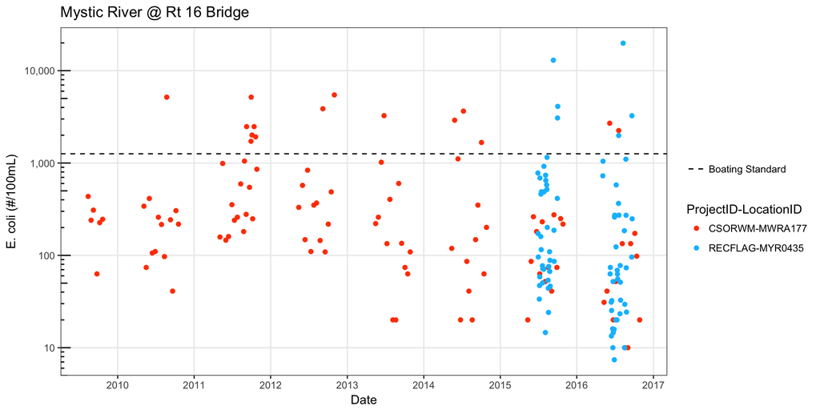

Dataset was split into training (75%) and testing (25%) subsets.

```
##          yes  no Total
## Training  16 122   138
## Testing    5  40    45
## Total     21 162   183
```

## 2.2 Prediction Model

The logistic regression model for the Mystic River is based on 3 predictors:

- `precip_sum_p24hr_lag0hr`: total rainfall (inches) over 24 hours prior to sample timestamp
- `precip_sum_p24hr_lag24hr`: total rainfall (inches) between 24 and 48 hours prior to sample timestamp
- `hours_since_050in_precip_event`: number of hours since last 0.5 inch rainfall event

Note that the sum of `precip_sum_p24hr_lag0hr + precip_sum_p24hr_lag24hr` is equal to the 48-hour antecedent rainfall. However, splitting that amount into two separate variables resulted in a better model. They are also not strongly correlated.

All predictors were centered and scaled prior to fitting.

Diagnostic output of the logistic regression model:

```
##
## Call:
## NULL
##
## Deviance Residuals:
##     Min       1Q   Median       3Q      Max
## -2.7030   0.2280   0.2758   0.3597   2.0812
##
## Coefficients:
##                                Estimate Std. Error z value Pr(>|z|)
## (Intercept)                      2.5727     0.3804   6.762 1.36e-11 ***
## precip_sum_p24hr_lag0hr         -1.5384     0.3761  -4.090 4.31e-05 ***
## precip_sum_p24hr_lag24hr        -0.4526     0.2748  -1.647   0.0996 .
## hours_since_050in_precip_event  -0.4421     0.3643  -1.214   0.2249
## ---
## Signif. codes:  0 '***' 0.001 '**' 0.01 '*' 0.05 '.' 0.1 ' ' 1
##
## (Dispersion parameter for binomial family taken to be 1)
##
##     Null deviance: 99.018  on 137  degrees of freedom
## Residual deviance: 66.262  on 134  degrees of freedom
## AIC: 74.262
##
## Number of Fisher Scoring iterations: 6
```

Relationships between E. coli concentration and value of each predictor.

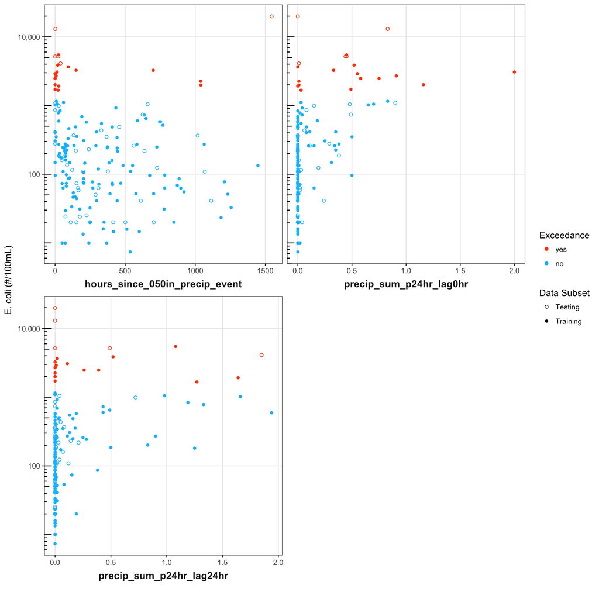

## 2.3 ROC Curves

| Data Subset | Area Under Curve (AUC) |
| --- | --- |
| Testing | 0.910000 |
| Training | 0.892418 |

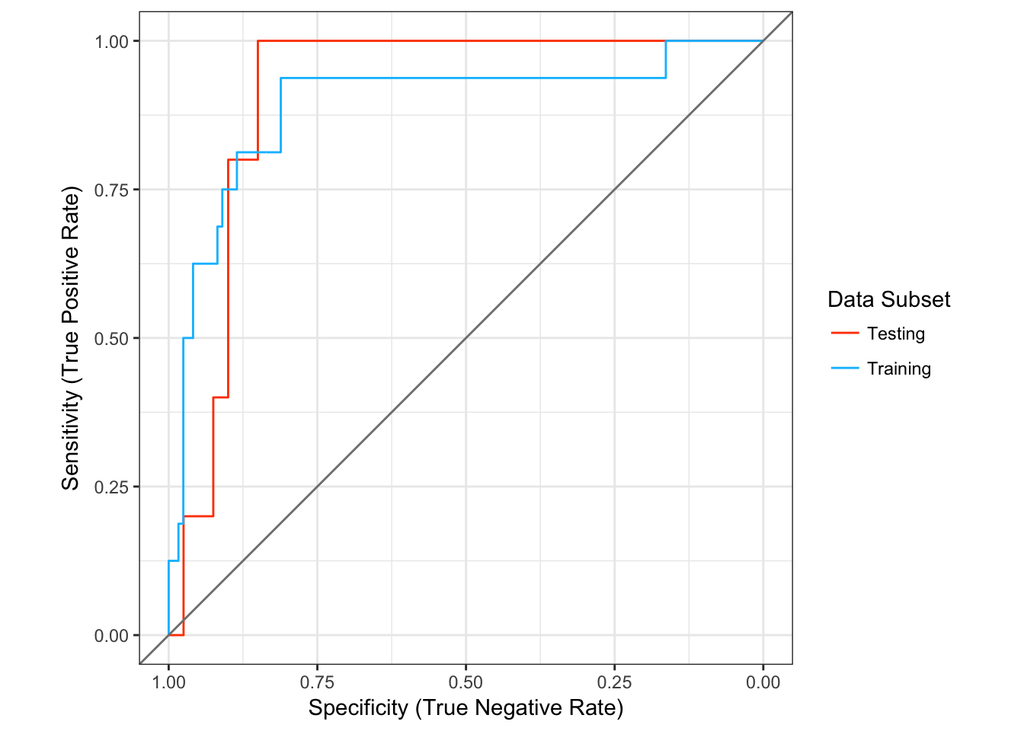

## 2.4 Cutoff Optimization

The logistic regression model predicts the probability of an exceedance. In order to classify that probability as being an exceedance or not, we need to determine an optimal cutoff probability. By default, logistic regression algorithms tend to use 0.5 as the cutoff. However, when the dataset has large class imbalance (exceedances are far less frequent than non-exceedances), then the optimal cutoff probability can be higher or lower than 0.5. One way to determine the optimal cutoff is to compute the accuracy (Number of Accurate Predictions), specificity (True Negative Rate), and sensitivity (True Positive Rate) for a range of cutoff thresholds. The following plots show these three metrics using both the training and testing subsets. The `distance` metric is the combined distance of both the sensitivity and specificity to values of 1. The goal is to minimize the distance metric, while not sacrificing accuracy. The optimal cutoff for this model was determined to be about 0.2.

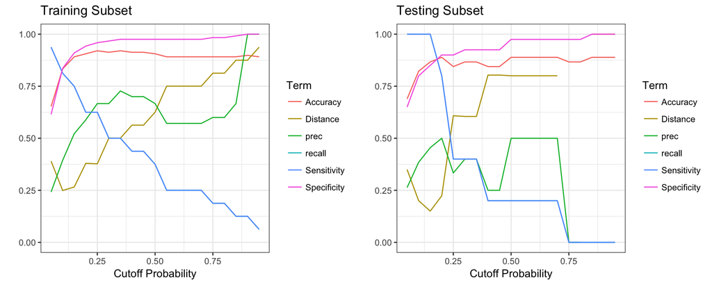

## 2.5 Confusion Matrix

For the training dataset, the following shows various metrics using the confusion matrix (i.e. tabulation of true positive, false negative, true negative, and false positive). The overall accuracy should be greater than the No Information Rate, which is simply the proportion of non-exceedance samples in the dataset. If the accuracy is less than the No Information Rate, then a naive model based solely on the proportion of exceedances and non-exceedances is a better predictor than the model.

```
## Confusion Matrix and Statistics
##
##           Reference
## Prediction yes  no
##        yes  10   7
##        no    6 115
##
##                Accuracy : 0.9058
##                  95% CI : (0.8443, 0.9489)
##     No Information Rate : 0.8841
##     P-Value [Acc > NIR] : 0.2594
##
##                   Kappa : 0.5526
##  Mcnemar's Test P-Value : 1.0000
##
##             Sensitivity : 0.62500
##             Specificity : 0.94262
##          Pos Pred Value : 0.58824
##          Neg Pred Value : 0.95041
##              Prevalence : 0.11594
##          Detection Rate : 0.07246
##    Detection Prevalence : 0.12319
##       Balanced Accuracy : 0.78381
##
##        'Positive' Class : yes
##
```

For the test dataset, the confusion matrix and associated summary metrics are:

```
## Confusion Matrix and Statistics
##
##           Reference
## Prediction yes no
##        yes   4  4
##        no    1 36
##
##                Accuracy : 0.8889
##                  95% CI : (0.7595, 0.9629)
##     No Information Rate : 0.8889
##     P-Value [Acc > NIR] : 0.6162
##
##                   Kappa : 0.5545
##  Mcnemar's Test P-Value : 0.3711
##
##             Sensitivity : 0.80000
##             Specificity : 0.90000
##          Pos Pred Value : 0.50000
##          Neg Pred Value : 0.97297
##              Prevalence : 0.11111
##          Detection Rate : 0.08889
##    Detection Prevalence : 0.17778
##       Balanced Accuracy : 0.85000
##
##        'Positive' Class : yes
##
```

## 2.6 Cross-Validation

During model development, the logistic regression model was fitted to 30 random resamples of the training subset using 10-fold cross-validation repeated 3 times. For each resample, the coefficients were fitted and then ROC statistics computed using a cutoff probability of 0.2. This boxplot shows the distribution of each statistic across the 30 resamples (red circle = mean). This figure gives some indication as to how sensitive the model is to the specific dataset. The final model was fitted to all of the data in the training subset.

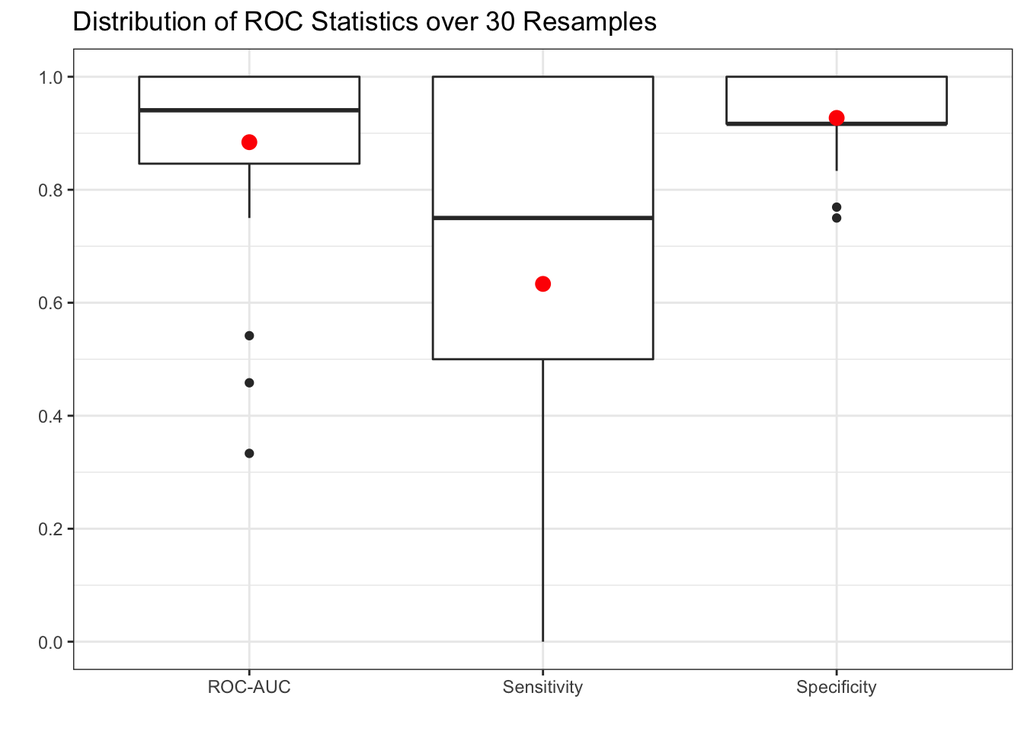

# 3 Lower Malden River at Rt 16 Bridge (E. coli)

## 3.1 Dataset

Number of exceedance (`yes`) and non-exceedance (`no`) samples by project and monitoring location.

```
##                   yes  no Total
## CSORWM - MWRA176   26 210   236
## RECFLAG - MAR0065   9  69    78
## Total              35 279   314
```

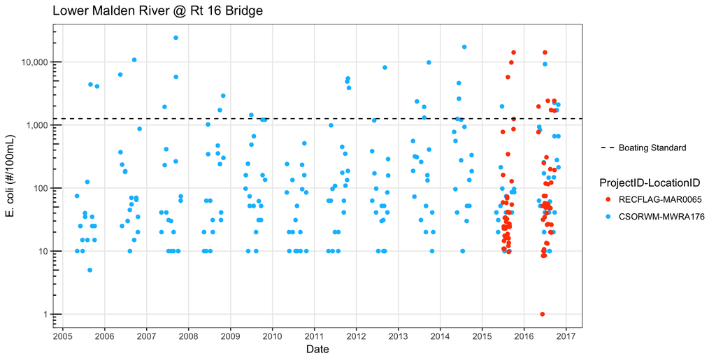

Dataset was split into training (75%) and testing (25%) subsets.

```
##          yes  no Total
## Training  27 210   237
## Testing    8  69    77
## Total     35 279   314
```

## 3.2 Prediction Model

- `precip_sum_p24hr_lag0hr`: total rainfall (inches) over 24 hours prior to sample timestamp
- `precip_sum_p24hr_lag24hr`: total rainfall (inches) between 24 and 48 hours prior to sample timestamp
- `hours_since_100in_precip_event`: number of hours since last 1.0 inch rainfall event
- `pressure_change_p72hr`: change in barometric pressure (inHg) from 72 hours prior to sample timestamp (when negative, indicates storms moving in)
- `temp_change_p72hr`: change in air temperature (degF) from 72 hours prior to sample timestamp

Note that the sum of `precip_sum_p24hr_lag0hr + precip_sum_p24hr_lag24hr` is equal to the 48-hour antecedent rainfall. However, splitting that amount into two separate variables resulted in a better model. They are also not strongly correlated.

All predictors were centered and scaled prior to fitting.

Diagnostic output of the logistic regression model:

```
##
## Call:
## NULL
##
## Deviance Residuals:
##     Min       1Q   Median       3Q      Max
## -2.7908   0.1088   0.2001   0.3294   1.5014
##
## Coefficients:
##                                Estimate Std. Error z value Pr(>|z|)
## (Intercept)                      3.1521     0.4176   7.549 4.39e-14 ***
## precip_sum_p24hr_lag0hr         -1.2656     0.2905  -4.357 1.32e-05 ***
## precip_sum_p24hr_lag24hr        -0.7792     0.2425  -3.214  0.00131 **
## hours_since_100in_precip_event  -0.6612     0.2669  -2.477  0.01324 *
## pressure_change_p72hr            1.1378     0.3525   3.228  0.00125 **
## temp_change_p72hr                0.7718     0.3494   2.209  0.02717 *
## ---
## Signif. codes:  0 '***' 0.001 '**' 0.01 '*' 0.05 '.' 0.1 ' ' 1
##
## (Dispersion parameter for binomial family taken to be 1)
##
##     Null deviance: 168.100  on 236  degrees of freedom
## Residual deviance:  90.726  on 231  degrees of freedom
## AIC: 102.73
##
## Number of Fisher Scoring iterations: 6
```

Relationships between E. coli concentration and value of each predictor.

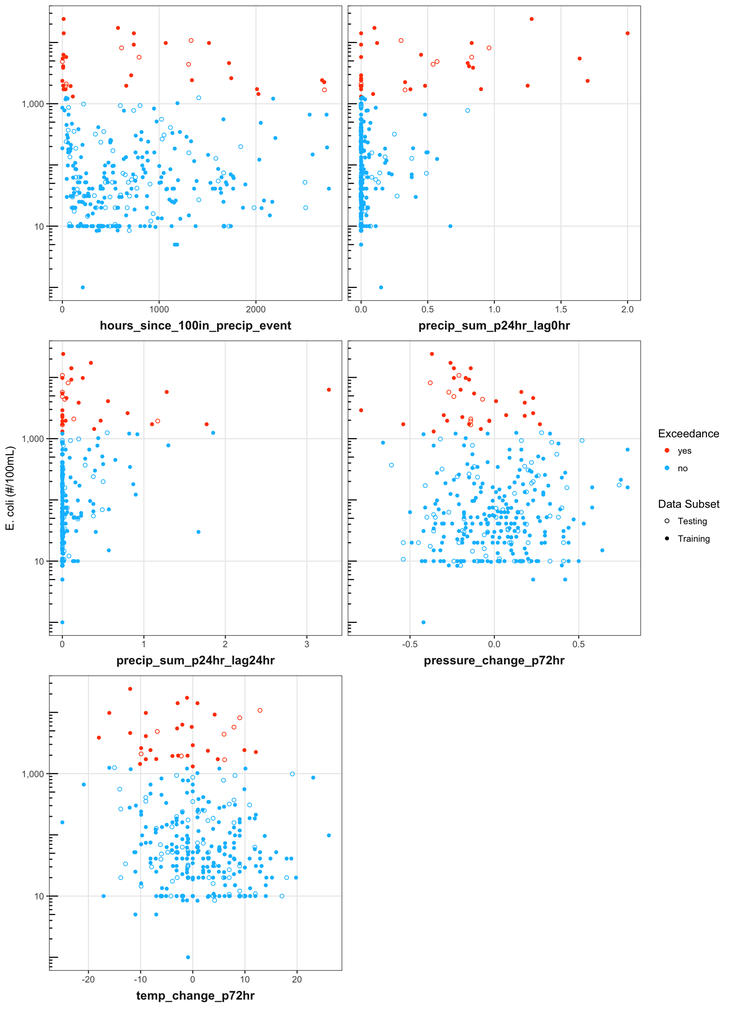

## 3.3 ROC Curves

| Data Subset | Area Under Curve (AUC) |
| --- | --- |
| Testing | 0.9311594 |
| Training | 0.9179894 |

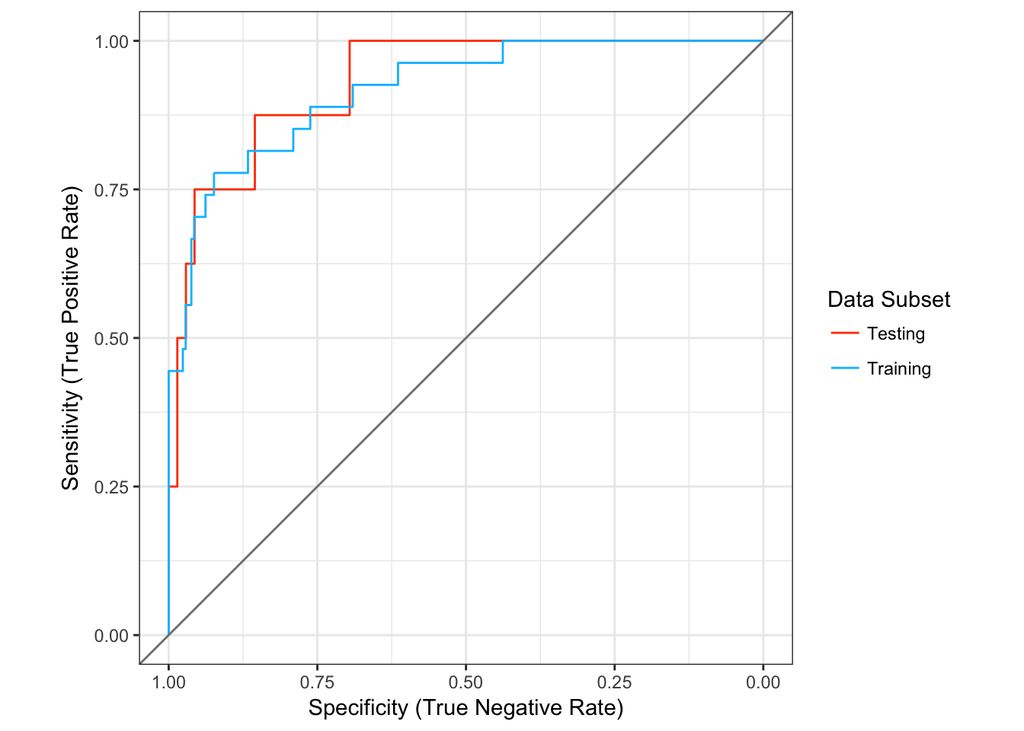

## 3.4 Cutoff Optimization

The logistic regression model predicts the probability of an exceedance. In order to classify that probability as being an exceedance or not, we need to determine an optimal cutoff probability. By default, logistic regression algorithms tend to use 0.5 as the cutoff. However, when the dataset has large class imbalance (exceedances are far less frequent than non-exceedances), then the optimal cutoff probability can be higher or lower than 0.5. One way to determine the optimal cutoff is to compute the accuracy (Number of Accurate Predictions), specificity (True Negative Rate), and sensitivity (True Positive Rate) for a range of cutoff thresholds. The following plots show these three metrics using both the training and testing subsets. The `distance` metric is the combined distance of both the sensitivity and specificity to values of 1. The goal is to minimize the distance metric, while not sacrificing accuracy. The optimal cutoff for this model was determined to be about 0.2.

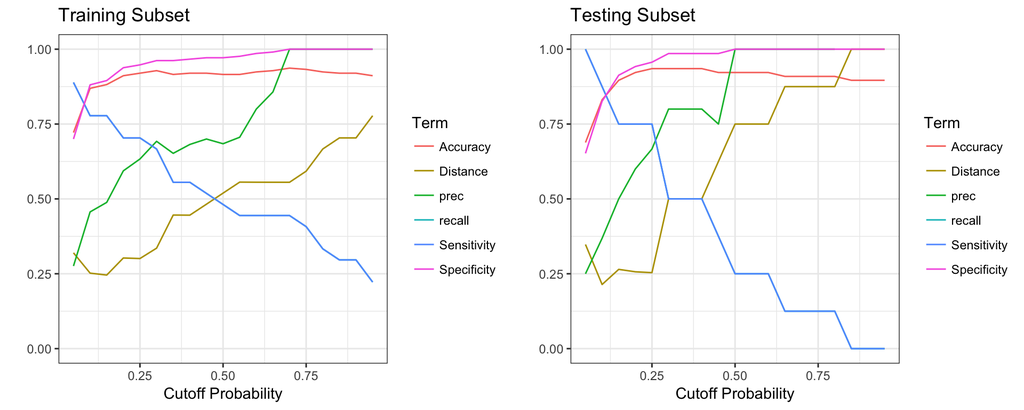

## 3.5 Confusion Matrix

For the training dataset, the following shows various metrics using the confusion matrix (i.e. tabulation of true positive, false negative, true negative, and false positive). The overall accuracy should be greater than the No Information Rate, which is simply the proportion of non-exceedance samples in the dataset. If the accuracy is less than the No Information Rate, then a naive model based solely on the proportion of exceedances and non-exceedances is a better predictor than the model.

```
## Confusion Matrix and Statistics
##
##           Reference
## Prediction yes  no
##        yes  19  13
##        no    8 197
##
##                Accuracy : 0.9114
##                  95% CI : (0.8677, 0.9443)
##     No Information Rate : 0.8861
##     P-Value [Acc > NIR] : 0.1285
##
##                   Kappa : 0.5939
##  Mcnemar's Test P-Value : 0.3827
##
##             Sensitivity : 0.70370
##             Specificity : 0.93810
##          Pos Pred Value : 0.59375
##          Neg Pred Value : 0.96098
##              Prevalence : 0.11392
##          Detection Rate : 0.08017
##    Detection Prevalence : 0.13502
##       Balanced Accuracy : 0.82090
##
##        'Positive' Class : yes
##
```

For the test dataset, the confusion matrix and associated summary metrics are:

```
## Confusion Matrix and Statistics
##
##           Reference
## Prediction yes no
##        yes   6  4
##        no    2 65
##
##                Accuracy : 0.9221
##                  95% CI : (0.8381, 0.9709)
##     No Information Rate : 0.8961
##     P-Value [Acc > NIR] : 0.2999
##
##                   Kappa : 0.6232
##  Mcnemar's Test P-Value : 0.6831
##
##             Sensitivity : 0.75000
##             Specificity : 0.94203
##          Pos Pred Value : 0.60000
##          Neg Pred Value : 0.97015
##              Prevalence : 0.10390
##          Detection Rate : 0.07792
##    Detection Prevalence : 0.12987
##       Balanced Accuracy : 0.84601
##
##        'Positive' Class : yes
##
```

## 3.6 Cross-Validation

During model development, the logistic regression model was fitted to 30 random resamples of the training subset using 10-fold cross-validation repeated 3 times. For each resample, the coefficients were fitted and then ROC statistics computed using a cutoff probability of 0.2. This boxplot shows the distribution of each statistic across the 30 resamples (red circle = mean). This figure gives some indication as to how sensitive the model is to the specific dataset. The final model was fitted to all of the data in the training subset.

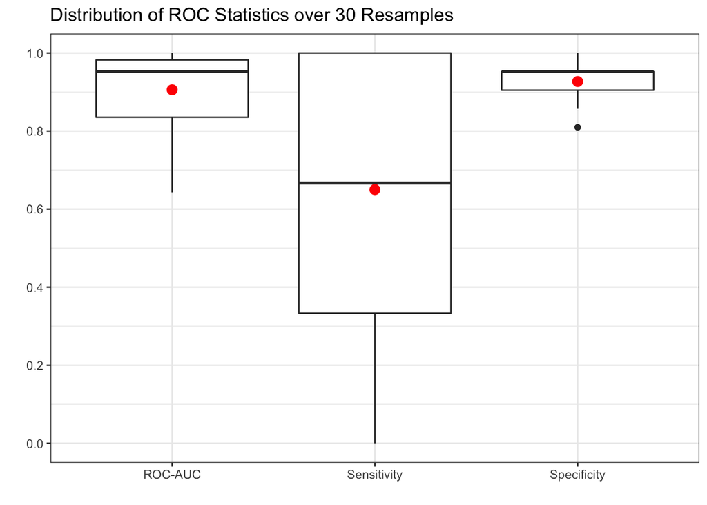

# 4 Shannon Beach at Upper Mystic Lake (Ent)

## 4.1 Dataset

Number of exceedance (`yes`) and non-exceedance (`no`) samples by project and monitoring location.

```
##                   yes  no Total
## DCRBCH - UPLSHBM   10 224   234
## RECFLAG - UPLSHBC   3  72    75
## Total              13 296   309
```

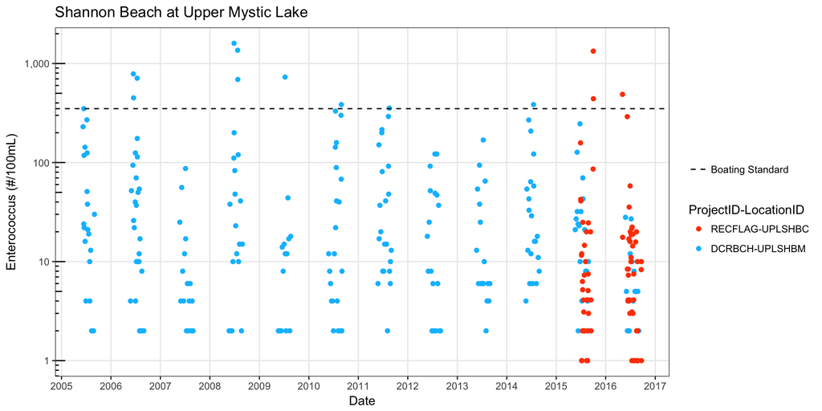

Dataset was split into training (75%) and testing (25%) subsets.

```
##          yes  no Total
## Training  10 222   232
## Testing    3  74    77
## Total     13 296   309
```

## 4.2 Prediction Model

- `aberjona_logflow_p1d`: daily mean streamflow (log-10 transformed) at Aberjona River gauge (Station ID: `01102500`) on the day before sample was collected

All predictors were centered and scaled prior to fitting.

Diagnostic output of the logistic regression model:

```
##
## Call:
## NULL
##
## Deviance Residuals:
##      Min        1Q    Median        3Q       Max
## -2.89322   0.05378   0.10094   0.20426   1.39868
##
## Coefficients:
##                      Estimate Std. Error z value Pr(>|z|)
## (Intercept)            5.0049     0.8355    5.99  2.1e-09 ***
## aberjona_logflow_p1d  -2.2503     0.5161   -4.36  1.3e-05 ***
## ---
## Signif. codes:  0 '***' 0.001 '**' 0.01 '*' 0.05 '.' 0.1 ' ' 1
##
## (Dispersion parameter for binomial family taken to be 1)
##
##     Null deviance: 82.446  on 231  degrees of freedom
## Residual deviance: 50.768  on 230  degrees of freedom
## AIC: 54.768
##
## Number of Fisher Scoring iterations: 8
```

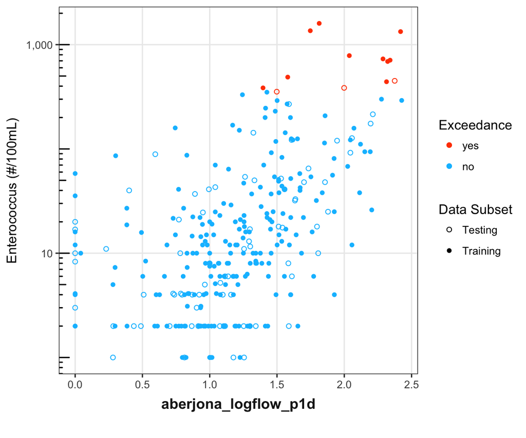

## 4.3 ROC Curves

| Data Subset | Area Under Curve (AUC) |
| --- | --- |
| Testing | 0.8828829 |
| Training | 0.9247748 |

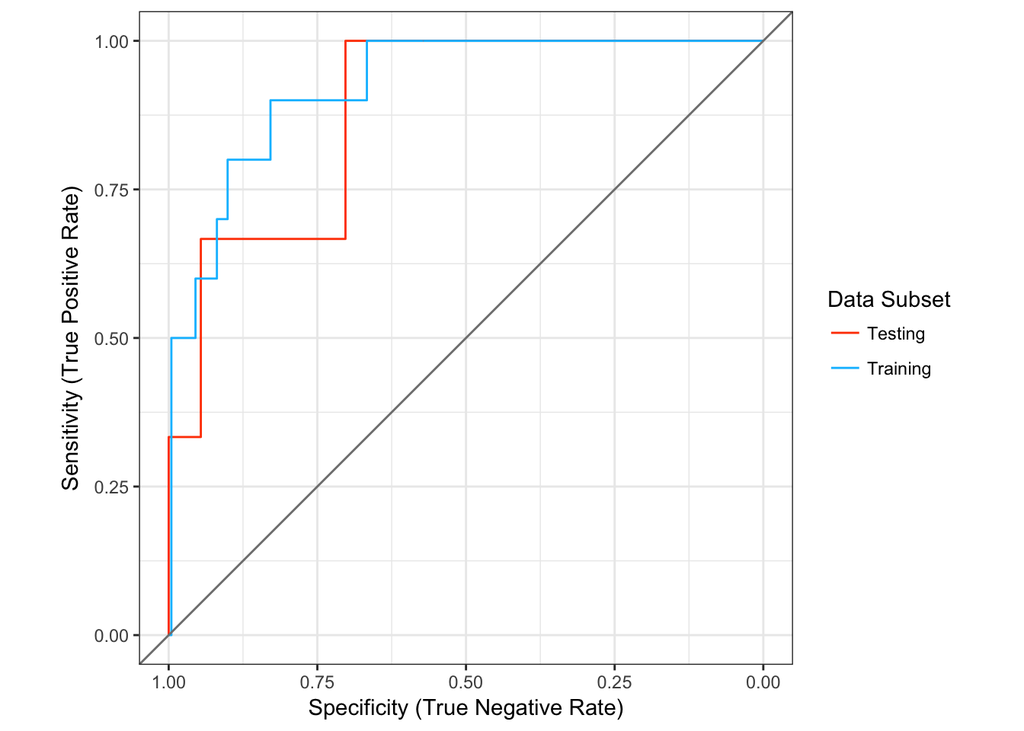

## 4.4 Cutoff Optimization

The logistic regression model predicts the probability of an exceedance. In order to classify that probability as being an exceedance or not, we need to determine an optimal cutoff probability. By default, logistic regression algorithms tend to use 0.5 as the cutoff. However, when the dataset has large class imbalance (exceedances are far less frequent than non-exceedances), then the optimal cutoff probability can be higher or lower than 0.5. One way to determine the optimal cutoff is to compute the accuracy (Number of Accurate Predictions), specificity (True Negative Rate), and sensitivity (True Positive Rate) for a range of cutoff thresholds. The following plots show these three metrics using both the training and testing subsets. The `distance` metric is the combined distance of both the sensitivity and specificity to values of 1. The goal is to minimize the distance metric, while not sacrificing accuracy. The optimal cutoff for this model was determined to be about 0.2.

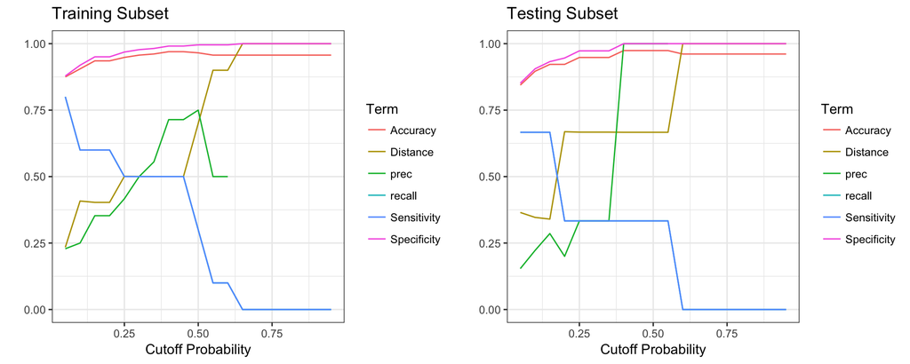

## 4.5 Confusion Matrix

For the training dataset, the following shows various metrics using the confusion matrix (i.e. tabulation of true positive, false negative, true negative, and false positive). The overall accuracy should be greater than the No Information Rate, which is simply the proportion of non-exceedance samples in the dataset. If the accuracy is less than the No Information Rate, then a naive model based solely on the proportion of exceedances and non-exceedances is a better predictor than the model.

```
## Confusion Matrix and Statistics
##
##           Reference
## Prediction yes  no
##        yes   6  11
##        no    4 211
##
##                Accuracy : 0.9353
##                  95% CI : (0.8956, 0.9634)
##     No Information Rate : 0.9569
##     P-Value [Acc > NIR] : 0.9550
##
##                   Kappa : 0.4126
##  Mcnemar's Test P-Value : 0.1213
##
##             Sensitivity : 0.60000
##             Specificity : 0.95045
##          Pos Pred Value : 0.35294
##          Neg Pred Value : 0.98140
##              Prevalence : 0.04310
##          Detection Rate : 0.02586
##    Detection Prevalence : 0.07328
##       Balanced Accuracy : 0.77523
##
##        'Positive' Class : yes
##
```

For the test dataset, the confusion matrix and associated summary metrics are:

```
## Confusion Matrix and Statistics
##
##           Reference
## Prediction yes no
##        yes   1  4
##        no    2 70
##
##                Accuracy : 0.9221
##                  95% CI : (0.8381, 0.9709)
##     No Information Rate : 0.961
##     P-Value [Acc > NIR] : 0.9695
##
##                   Kappa : 0.2116
##  Mcnemar's Test P-Value : 0.6831
##
##             Sensitivity : 0.33333
##             Specificity : 0.94595
##          Pos Pred Value : 0.20000
##          Neg Pred Value : 0.97222
##              Prevalence : 0.03896
##          Detection Rate : 0.01299
##    Detection Prevalence : 0.06494
##       Balanced Accuracy : 0.63964
##
##        'Positive' Class : yes
##
```

## 4.6 Cross-Validation

During model development, the logistic regression model was fitted to 30 random resamples of the training subset using 10-fold cross-validation repeated 3 times. For each resample, the coefficients were fitted and then ROC statistics computed using a cutoff probability of 0.2. This boxplot shows the distribution of each statistic across the 30 resamples (red circle = mean). This figure gives some indication as to how sensitive the model is to the specific dataset. The final model was fitted to all of the data in the training subset.

The sensitivity for this model is relatively low. However, this is to be expected given that only 4.21% of all samples were exceedances.

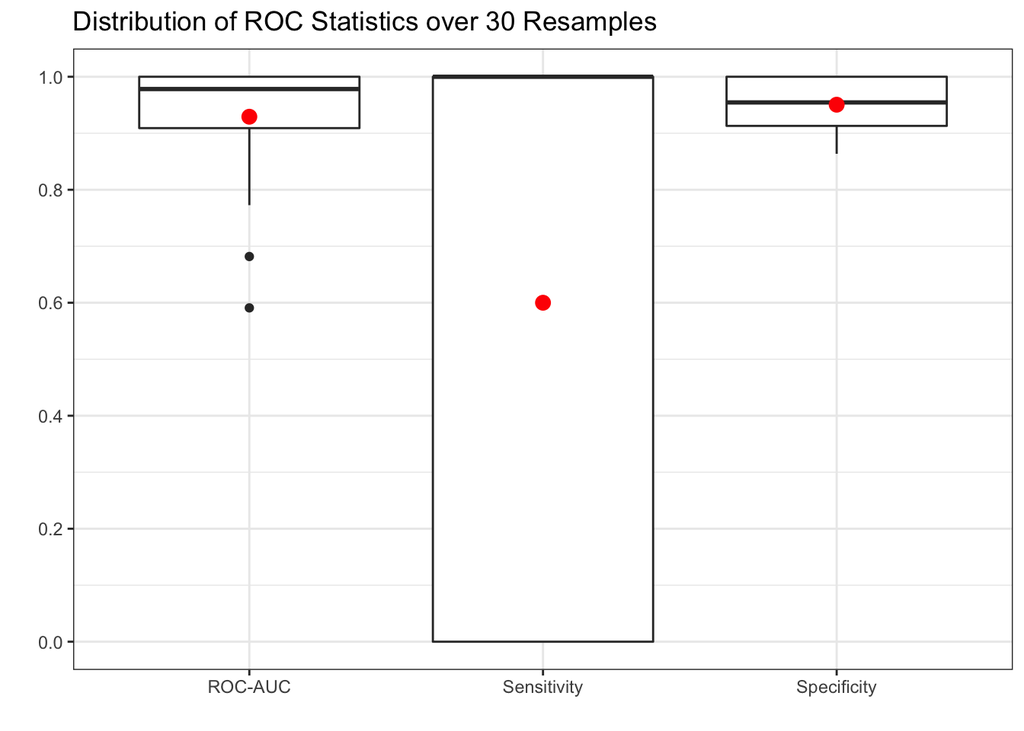